# Using the REDCap API for Data Management with REDCapR

Automating REDCap Data Access and Analysis in R

Nathan Van Bibber

## Learning Objectives

- Define **API**
- Describe how the REDCap API works
- Connect R to REDCap using `{REDCapR}`
- Read data directly into R
- Understand security best practices
- Identify opportunities for automation

## The Problem with Manual Exports

### Typical workflow

1. Log into REDCap
2. Export CSV
3. Save file locally
4. Open in Excel or R
5. Analyze data
6. Repeat

### Challenges

- Time consuming
- Multiple file versions
- Difficult to reproduce
- Increased risk of human error

What Is an API ?

API = Application Programming Interface

An API allows software applications to communicate with one another.

### Restaurant analogy

- You request an entrée
- Waiter delivers your request
- Kitchen prepares your order
- Waiter serves your food

### API analog

- R requests records
- API contacts REDCap
- REDCap prepares your data
- API returns the result to R

## Advantages of using an API

### Efficient

- No repeated downloads
- Automated data refreshes

### Reproducible

- Same code
- Same process
- Same documentation

### Scalable

- Larger projects
- Multiple studies
- Automated reporting

but interacting with APIs directly can be complicated…

## What Is REDCapR?

### REDCapR

[figure not shown]

An R package that simplifies interacting with the REDCap API.

### Why use it?

Focus on data instead of API details.

> Before encapsulating these functions in a package, we were replicating 50+ lines of code to contact REDCap and robustly transform the returned csv into an R data.frame… All this can be done in one call to `redcap_read()`.

## Requirements

✅ REDCap project access

✅ API enabled project

✅ API token

✅ R and RStudio

**Important**

- Treat API tokens like passwords
- Never share them
- Never commit them to GitHub

## Installing REDCapR

```r
install.packages("dplyr")
install.packages("REDCapR")
install.packages("usethis")

library(dplyr)
library(REDCapR)
```

## Connecting to REDCap

```r
library(REDCapR)

redcap_uri <-
  "https://yourinstitution.edu/redcap/api/"

token <- Sys.getenv("REDCAP_TOKEN")
```

**Best practice**

Store tokens in environment variables.

Use `{keyring}`!

Run `usethis::edit_r_environ()` to open your *.Renviron* file and add the following line.

```
REDCAP_TOKEN="PasteYourTokenHere"
```

## keyring

Securely manages tokens using your operating system’s credential store.

```r
# install.packages("pak")
pak::pak("keyring")
```

As simple as `key_set()` and `key_get()`

```r
library(keyring)

# Interactively save a secret. This avoids typing the value of the secret
# into the console as this could be recorded in your `.Rhistory`
key_set("redcap_token", username = "2047")
key_set("redcap_uri", username = "MCC")

# Later retrieve that secret
key_get("redcap_token", username = "2047")
key_get("redcap_uri", username = "MCC")

# If multiple projects each with a different token
key_list(service = "redcap_token")
```

### Common tasks

- Read records
- Export metadata
- Export reports
- Read the project logs
- Anticipate problems before writing
- Import records
- `redcap_read()`
- `redcap_metadata_read()`
- `redcap_report()`
- `redcap_log_read()`
- `validate_for_write()`
- `redcap_write()`

## Reading REDCap Records

```r
records <- redcap_read(
  redcap_uri = keyring::key_get("redcap_uri", username = "MCC"),
  token = keyring::key_get("redcap_token", username = "2047"),
  export_data_access_groups = TRUE,
  blank_for_gray_form_status = TRUE
)

data <- records$data
```

### Result

Data is now available as a dataframe in R.

## Working with Metadata

```r
metadata <-
  redcap_metadata_read(
    redcap_uri = keyring::key_get("redcap_uri", username = "MCC"),
    token = keyring::key_get("redcap_token", username = "2047")
  )
```

### Metadata includes

- Variable names
- Labels
- Validation rules
- Field types

## Upload Records to REDCap

```r
records <- redcap_write(
  ds_to_write = new_data,
  redcap_uri = keyring::key_get("redcap_uri", username = "MCC"),
  token = keyring::key_get("redcap_token", username = "2047")
  overwrite_with_blanks = FALSE
)

data <- records$data
```

### Result

Data have been written to REDCap.

## Take it Farther

- Custom functions
- Collect functions into a package
- Build dashboards
- Analysis pipelines
- Automate reports

```r
function (redcap_uri = redcap_uri, token = token, ...) {
    ACSR_clinical <-
      REDCapR::redcap_read(
        redcap_uri = redcap_uri,
        token = token,
        export_data_access_groups = TRUE,
        blank_for_gray_form_status = TRUE,
        ...
      )

    ACSR_clinical$pull_date <- Sys.time()

    ACSR_clinical$data_dictionary <-
      redcap_metadata_read(
        redcap_uri = redcap_uri,
        token = token
      )

    ACSR_clinical
}
```

Common pitfalls

## You can import anything!

The API will allow you to import almost anything. Validate your data before writing to REDCap!

- check column types
  - date fields
  - 0/1 values instead of logical
- make sure raw values (e.g. Radio button) have the same label
- remove all empty rows
- all necessary *pseudofields* are present

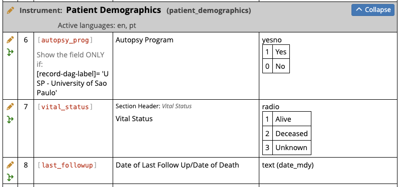

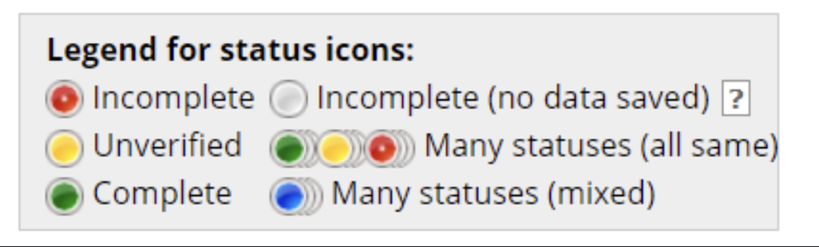

Use the `validate_*()` functions before writing to redcap.

Try the `*_oneshot()` if your function call isn’t working.

## Pseudofields

Pseudofields are internal REDCap fields. They are not defined by users and do not appear in the codebook, and are only exported for certain project structures.

## Best Practices

### Security

- Protect API tokens
- Limit access appropriately with DAGs

### Reproducibility

- Script workflows
- Use version control

### Quality Control

- Validate imports
- Verify record counts

## 5 Key Takeaways

1. APIs automate data access
2. REDCapR makes the API easy to use
3. Reproducibility improves with scripted workflows
4. Automation reduces manual effort and error
5. Start small and build from there

## Resources

- REDCapR documentation <sup>1</sup>
- REDCap API documentation <sup>2</sup>
- RStudio resources <sup>3</sup>
- Institutional REDCap support
  - PRISM Core
  - Me
[^1]: https://ouhscbbmc.github.io/REDCapR/index.html
[^2]: https://redcap.aws.moffitt.org/api/help/
[^3]: https://docs.posit.co/ide/user/

## Acknowledgments

- Sashanna Roman (PRISM Core)
- Kris Bowles
- Dr. Anna Coghill

Thank You!